# Assignment 5: Tidying and Transforming Data

Ellen Kim

2020-09-25

```r
library(plyr)
library(tidyverse)
library(openintro)
library(readr)
library(tidyr)
library(dplyr)
```

## High Level Overview

We’ve been presented with a dataset that aggregates to an airline level. The dataset is considered wide because each airport that corresponds to an airline is represented as individual columns. To add another more complexity, the dataset has two level of indexes for rows, airline and flight status (delayed, on time). My overall approach was to transpose the dataset so that cities become row values and the two flight status’s become columns.

## Read in raw data.

Reading from github. The data format is not normalized and has null columns which will render warning output but the data will load.

```r
data_url = "https://raw.githubusercontent.com/Lnkiim/DATA607FALL202/master/Week5/Assignment5_ek/flights_data.csv"
flights_raw <- read_csv(url(data_url))
```

```
## Warning: Missing column names filled in: 'X1' [1], 'X2' [2]
```

## Data Pivot

```r
# renaming headers
flights_raw <- flights_raw %>%
  rename("airline" = X1,
         "status" = X2    )

# fill airline values where null
flights<- flights_raw %>% tidyr::fill(airline)

# transpose dataframe
flights <- flights %>%
  gather(key = airports, value = flight_count, "Los Angeles":"Seattle")

# transpose status to columns
flights <- flights %>%
  spread(key = status, value = flight_count)

# rename column because space in a variable is bad practice
flights <-
  flights %>%
    rename(on_time = "on time")
```

## Analysis of Arrival Times

### Compare the overall on-time performance for both airlines.

On average, AM WEST has a higher rate of being on time than Alaska.

```r
flights %>%
  select(airline, delayed, on_time) %>%
    group_by(airline) %>%
      summarize(tot_flights = sum(delayed) + sum(on_time),
             total_onTime = sum(on_time),
             total_delayed = sum(delayed),
             onTime_rate = total_onTime / tot_flights,
             delayed_rate = total_delayed / tot_flights
             ) %>%
  select(airline,onTime_rate,delayed_rate)
```

```
## # A tibble: 2 x 3
##   airline onTime_rate delayed_rate
##   <chr>         <dbl>        <dbl>
## 1 Alaska        0.819        0.181
## 2 AM WEST       0.891        0.109
```

### Compare the per-city on-time performance for both airlines.

```r
flights_byCity <-
  flights %>%
    group_by(airline, airports) %>%
      summarize(tot_flights = sum(delayed) + sum(on_time),
             total_onTime = sum(on_time),
             onTime_rate = total_onTime / tot_flights
             ) %>%
          arrange(airports, airline)
```

### Data Visualization

Here we can see that the the overall higher average of AM WEST is greatly attributed to the weight of Phoenix.

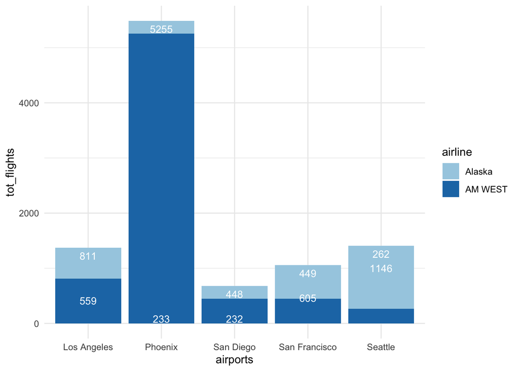

```r
#stacked bar chart to compare per city

# Calculate the cumulative sum of len for each dose
flights_rollingSum <- ddply(flights_byCity, "airports",
                   transform, label_ypos=cumsum(tot_flights))

 # Create the barplot
ggplot(data=flights_rollingSum, aes(x=airports, y=tot_flights, fill=airline)) +
  geom_bar(stat="identity")+
  geom_text(aes(y=label_ypos, label=tot_flights), vjust=1.6,
            color="white", size=3.5)+
  scale_fill_brewer(palette="Paired")+
  theme_minimal()
```

## Conclusion

It seems like weather is a significant factor in determing on-time rates. We can see that cities like Phoenix have a significant number of flights with a high rate of being on time and thats most likely because there isn’t much turbulent weather. Conversely if we observe cities like Seattle, where it rains frequently, we see more delays.